# coeff of variation

Allison Davis Connelly

2024-09-17

# Initial steps

## Data collection

```
## Using libcurl 8.3.0 with Schannel
```

## Checking normality

#### Log transformations

Since all of the continuous characters were not normal, I will log transform them, and proceed with the transformed data in all analyses.

```r
raw1[paste0(names(raw1), '_log')] <- log(raw1[, 26:35], 10)
#for some reason did the log of the whole data frame instead of those specific columns, so I will just remove the unnecessary columns instead of spending time on what went wrong.

raw1 <- raw1[-c(37:60)]
raw1 <- raw1[-c(48)]
```

Need to try other transformations for body depth, predorsal length, and dorsal base length. Will try squareroot or cuberoot to see what gets them normal. Cubed got them closest to normal (bd still not normal but other two are).

```r
#cubed root
raw1$cbR_BD ='^'(raw1$BD,1/3)
raw1$cbR_PreDL ='^'(raw1$PreDL,1/3)
raw1$cbR_DbL ='^'(raw1$DbL,1/3)


#need to cube root SL to use in regressions

raw1$cbR_SL ='^'(raw1$SL,1/3)
```

## Correcting for body size (residuals)

### SL correction

Since amazons are in general bigger than sailfin, we don’t want any results to be due to this difference in body size bias. Therefore, we will see what traits are influenced by body size (regressions) and correct for body size when necessary (absolute value of residuals). We can then use the residuals when comparing between species for traits that are influenced by body size, and raw/transformed data for traits that are not influenced by body size. I will also calculate standardized residuals to compare residuals across traits in later analyses.

#### Regressions

- STEP ONE: plot trait vs body size

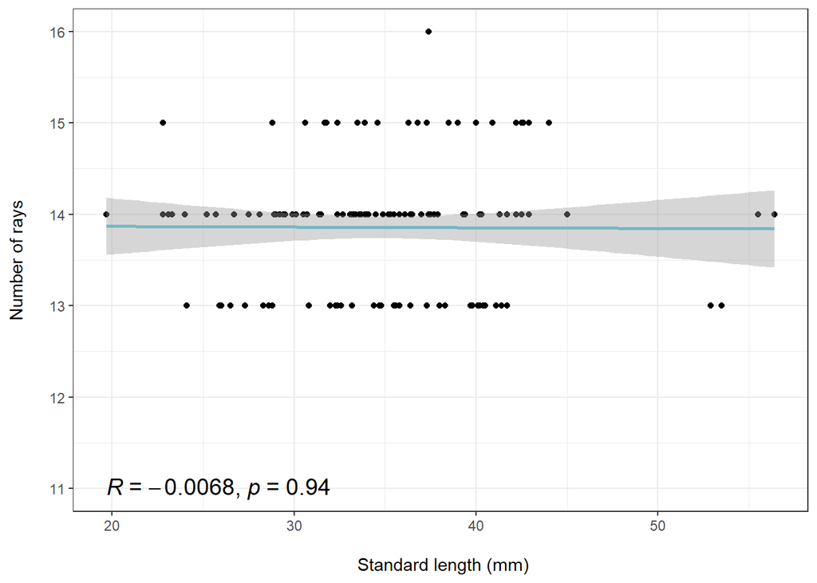

```r
library(ggplot2)
library(ggpubr)



lat <- raw1[raw1$SPP == "p.latipinna",]


form <- raw1[raw1$SPP == "p.formosa",]


mex <- raw1[raw1$SPP == "p.mexicana",]


##### LAT #####
par(mfcol=c(2,2), oma = c(0,0,2,0))

reg.lat.D <- lm(lat$D ~ lat$SL)
sd.lat.D <- rstandard(reg.lat.D)
reg.lat.D.plot <- ggplot(lat, aes(x = SL, y = D)) +
  geom_point() +
  stat_smooth(method = "lm", col = "#78B7C5") +
  stat_cor(label.y = 11,  size=5) + theme_bw() + labs(x= "\n Standard length (mm)", y="Number of rays\n")
reg.lat.D.plot
```

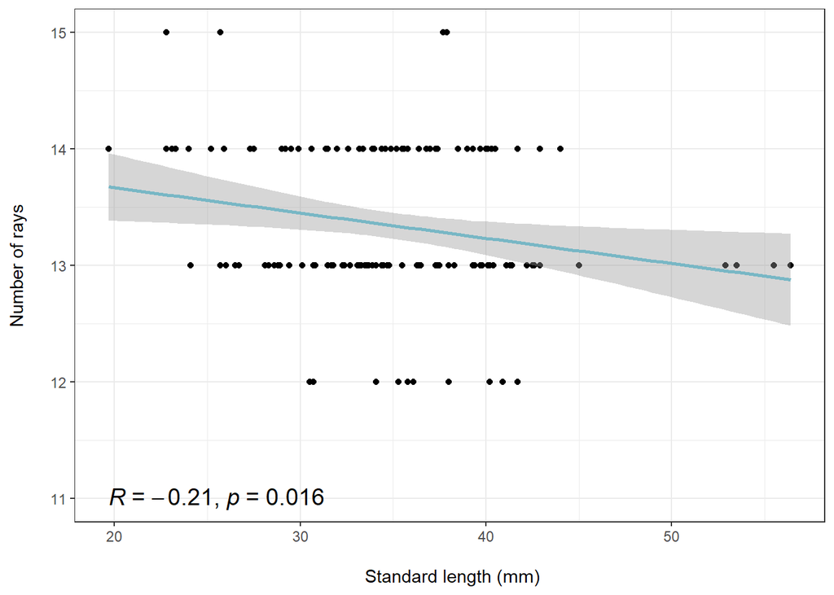

```r
reg.lat.P1 <- lm(lat$P1 ~ lat$SL)
sd.lat.P1 <- rstandard(reg.lat.P1)
reg.lat.P1.plot <- ggplot(lat, aes(x = SL, y = P1)) +
  geom_point() +
  stat_smooth(method = "lm", col = "#78B7C5") +
  stat_cor(label.y = 11, size=5)+ theme_bw() + labs(x= "\n Standard length (mm)", y="Number of rays\n")
reg.lat.P1.plot
```

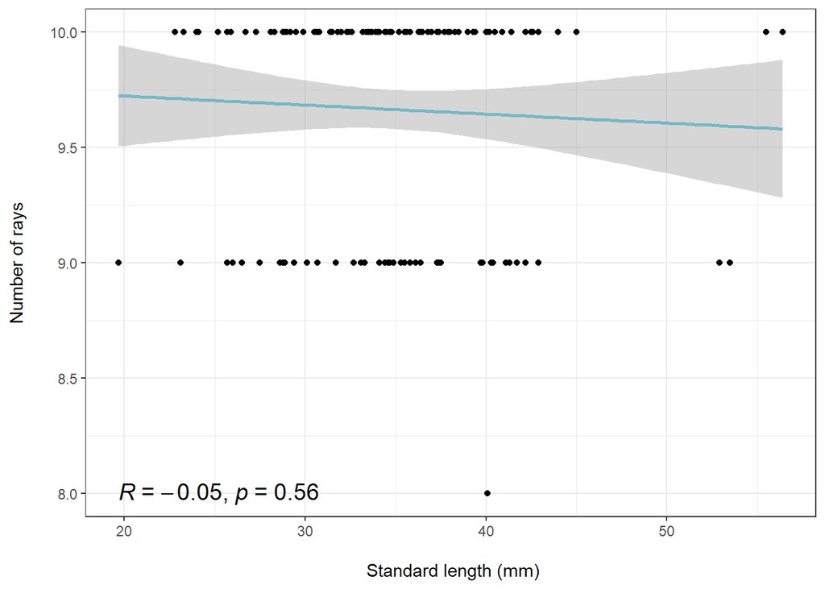

```r
reg.lat.A <- lm(lat$A ~ lat$SL)
sd.lat.A <- rstandard(reg.lat.A)
reg.lat.A.plot <- ggplot(lat, aes(x = SL, y = A)) +
  geom_point() +
  stat_smooth(method = "lm", col = "#78B7C5") +
  stat_cor(label.y = 8, size=5)+ theme_bw() + labs(x= "\n Standard length (mm)", y="Number of rays\n")
reg.lat.A.plot
```

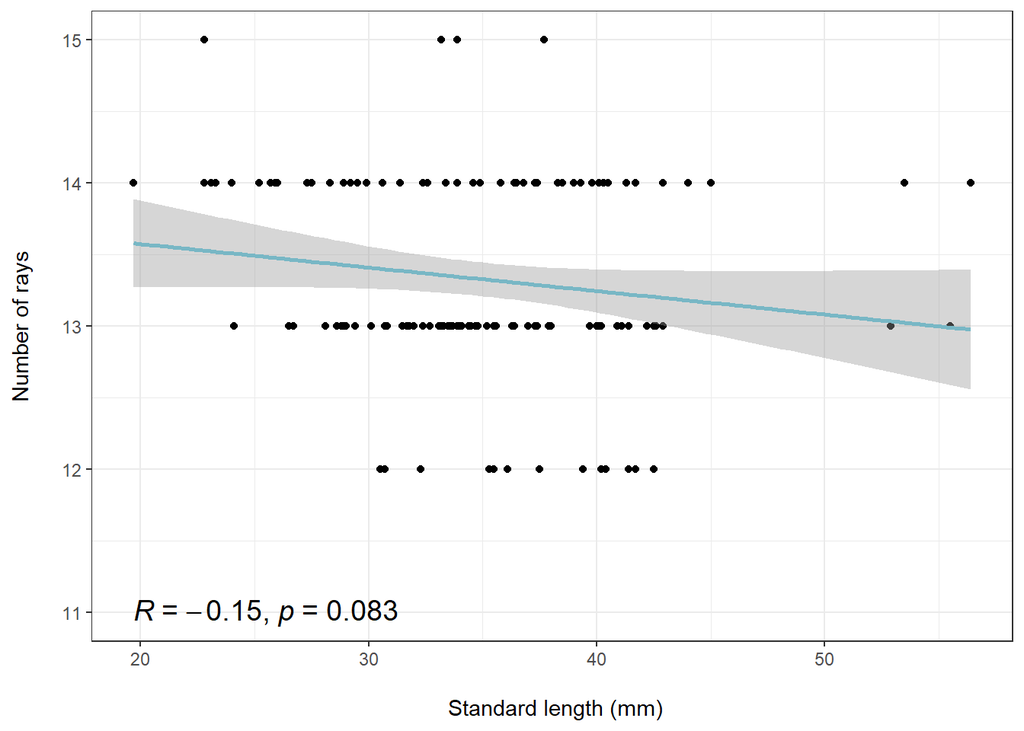

```r
reg.lat.P1.R <- lm(lat$P1.R ~ lat$SL)
sd.lat.P1.R <- rstandard(reg.lat.P1.R)
reg.lat.P1.R.plot <- ggplot(lat, aes(x = SL, y = P1.R)) +
  geom_point() +
  stat_smooth(method = "lm", col = "#78B7C5") +
  stat_cor(label.y = 11, size=5)+ theme_bw() + labs(x= "\n Standard length (mm)", y="Number of rays\n")
reg.lat.P1.R.plot
```

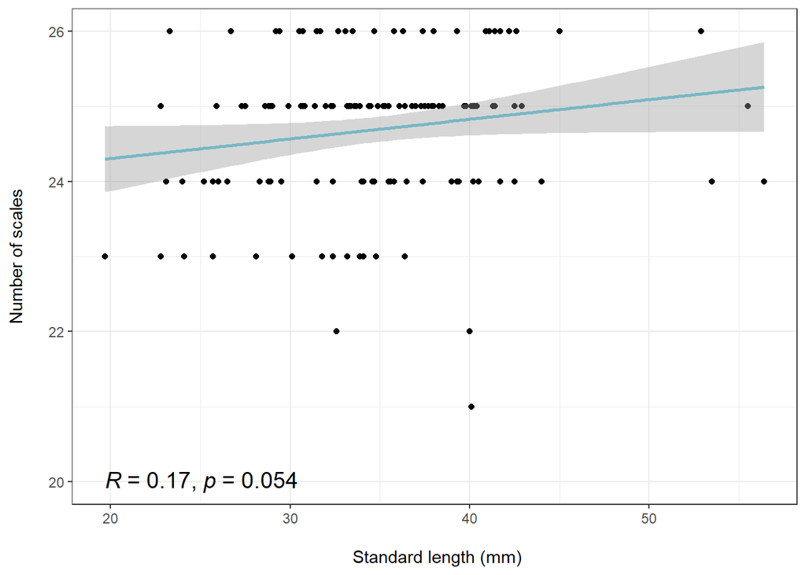

```r
reg.lat.LLSC <- lm(lat$LLSC ~ lat$SL)
sd.lat.LLSC <- rstandard(reg.lat.LLSC)
reg.lat.LLSC.plot <- ggplot(lat, aes(x = SL, y = LLSC)) +
  geom_point() +
  stat_smooth(method = "lm", col = "#78B7C5") +
  stat_cor(label.y = 20, size=5)+ theme_bw() + labs(x= "\n Standard length (mm)", y="Number of scales\n")
reg.lat.LLSC.plot
```

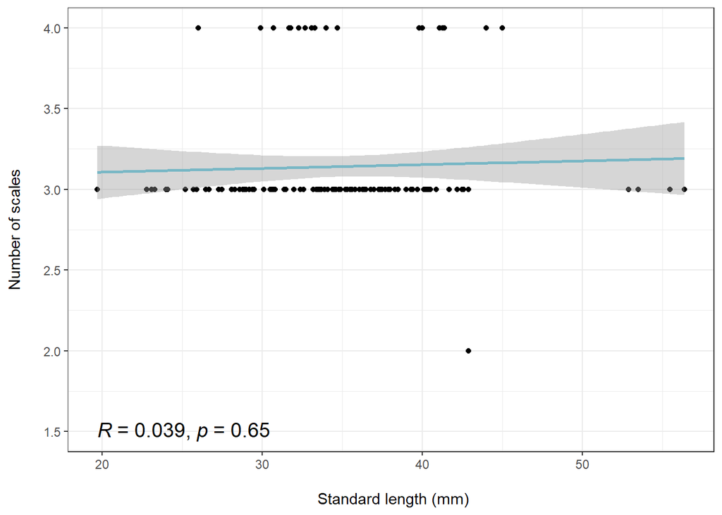

```r
reg.lat.SALL <- lm(lat$SALL ~ lat$SL)
sd.lat.SALL <- rstandard(reg.lat.SALL)
reg.lat.SALL.plot <- ggplot(lat, aes(x = SL, y = SALL)) +
  geom_point() +
  stat_smooth(method = "lm", col = "#78B7C5") +
  stat_cor(label.y = 1.5, size=5)+ theme_bw() + labs(x= "\n Standard length (mm)", y="Number of scales\n")
reg.lat.SALL.plot
```

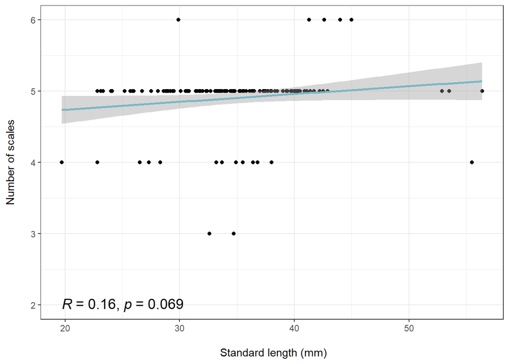

```r
reg.lat.SBLL <- lm(lat$SBLL ~ lat$SL)
sd.lat.SBLL <- rstandard(reg.lat.SBLL)
reg.lat.SBLL.plot <- ggplot(lat, aes(x = SL, y = SBLL)) +
  geom_point() +
  stat_smooth(method = "lm", col = "#78B7C5") +
  stat_cor(label.y = 2, size=5)+ theme_bw() + labs(x= "\n Standard length (mm)", y="Number of scales\n")
reg.lat.SBLL.plot
```

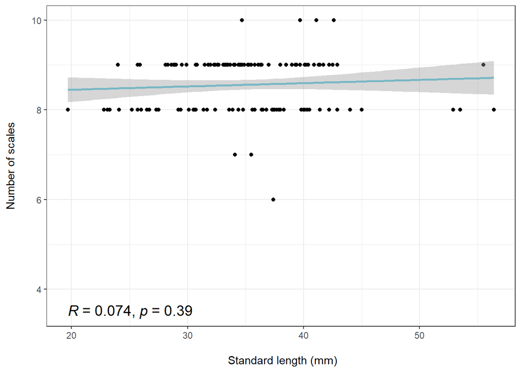

```r
reg.lat.SBDF <- lm(lat$SBDF ~ lat$SL)
sd.lat.SBDF <- rstandard(reg.lat.SBDF)
reg.lat.SBDF.plot <- ggplot(lat, aes(x = SL, y = SBDF)) +
  geom_point() +
  stat_smooth(method = "lm", col = "#78B7C5") +
  stat_cor(label.y = 3.5, size=5)+ theme_bw() + labs(x= "\n Standard length (mm)", y="Number of scales\n")
reg.lat.SBDF.plot
```

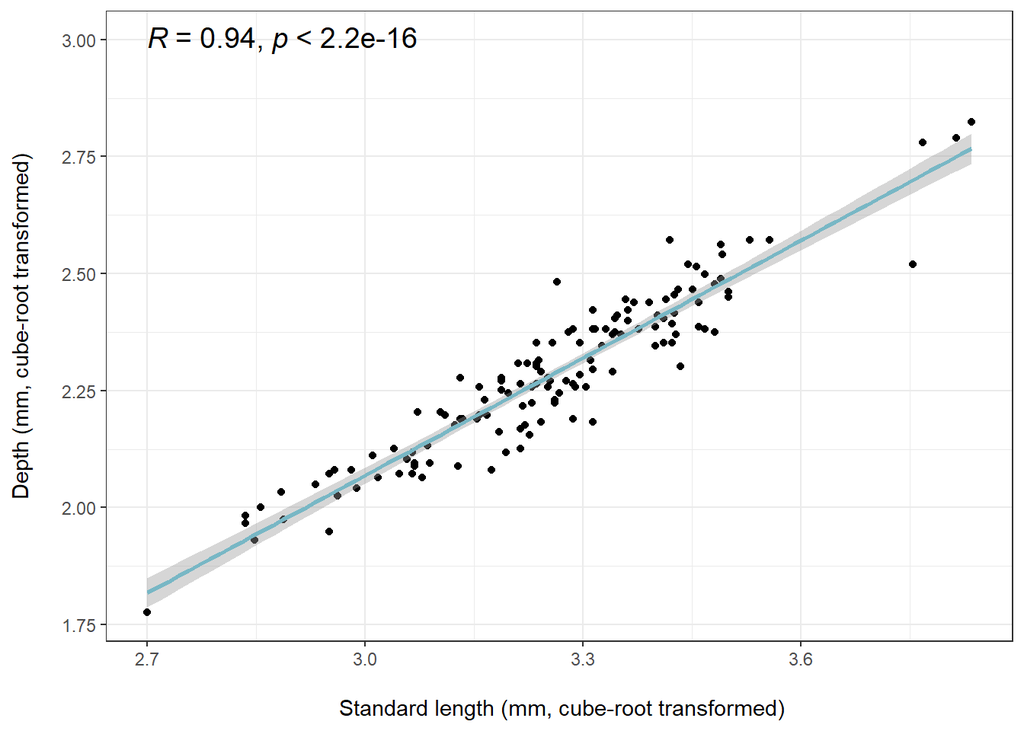

```r
reg.lat.BD <- lm(lat$cbR_BD ~ lat$cbR_SL)
sd.lat.BD <- rstandard(reg.lat.BD)
reg.lat.BD.plot <- ggplot(lat, aes(x = cbR_SL, y = cbR_BD)) +
  geom_point() +
  stat_smooth(method = "lm", col = "#78B7C5") +
  stat_cor(label.y = 3, size=5)+ theme_bw() + labs(x= "\n Standard length (mm, cube-root transformed)", y="Depth (mm, cube-root transformed)\n")
reg.lat.BD.plot
```

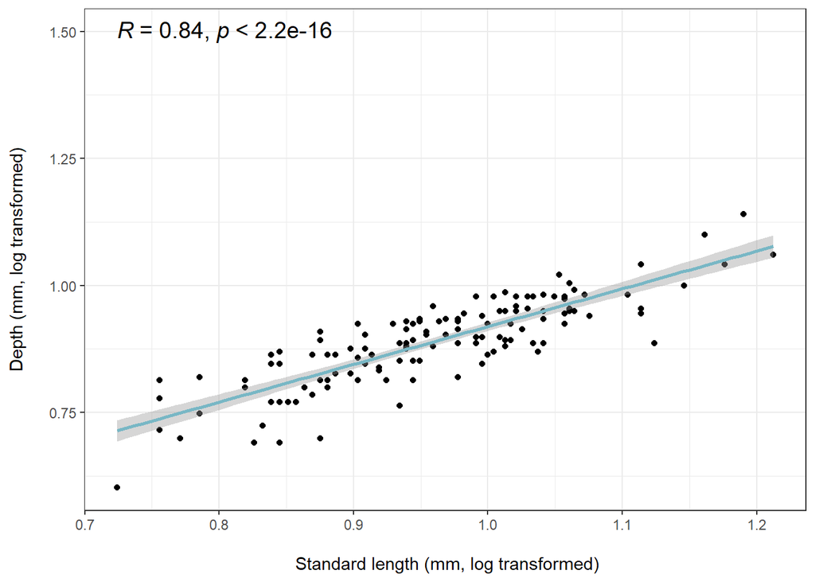

```r
reg.lat.CPD <- lm(lat$CPD_log ~ lat$SL_log)
sd.lat.CPD <- rstandard(reg.lat.CPD)
reg.lat.CPD.plot <- ggplot(lat, aes(x = SL_log, y = CPD_log)) +
  geom_point() +
  stat_smooth(method = "lm", col = "#78B7C5") +
  stat_cor(label.y = 1.5, size=5)+ theme_bw() + labs(x= "\n Standard length (mm, log transformed)", y="Depth (mm, log transformed)\n")
reg.lat.CPD.plot
```

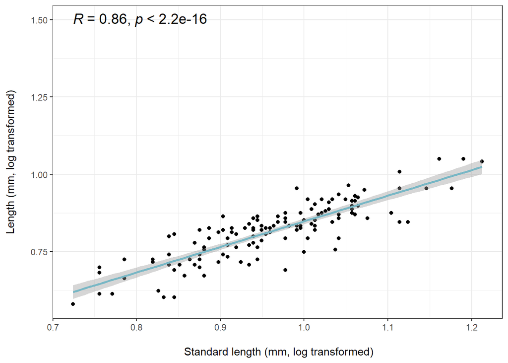

```r
reg.lat.CPL <- lm(lat$CPL_log ~ lat$SL_log)
sd.lat.CPL <- rstandard(reg.lat.CPL)
reg.lat.CPL.plot <- ggplot(lat, aes(x = SL_log, y = CPL_log)) +
  geom_point() +
  stat_smooth(method = "lm", col = "#78B7C5") +
  stat_cor(label.y = 1.5, size=5)+ theme_bw() + labs(x= "\n Standard length (mm, log transformed)", y="Length (mm, log transformed)\n")
reg.lat.CPL.plot
```

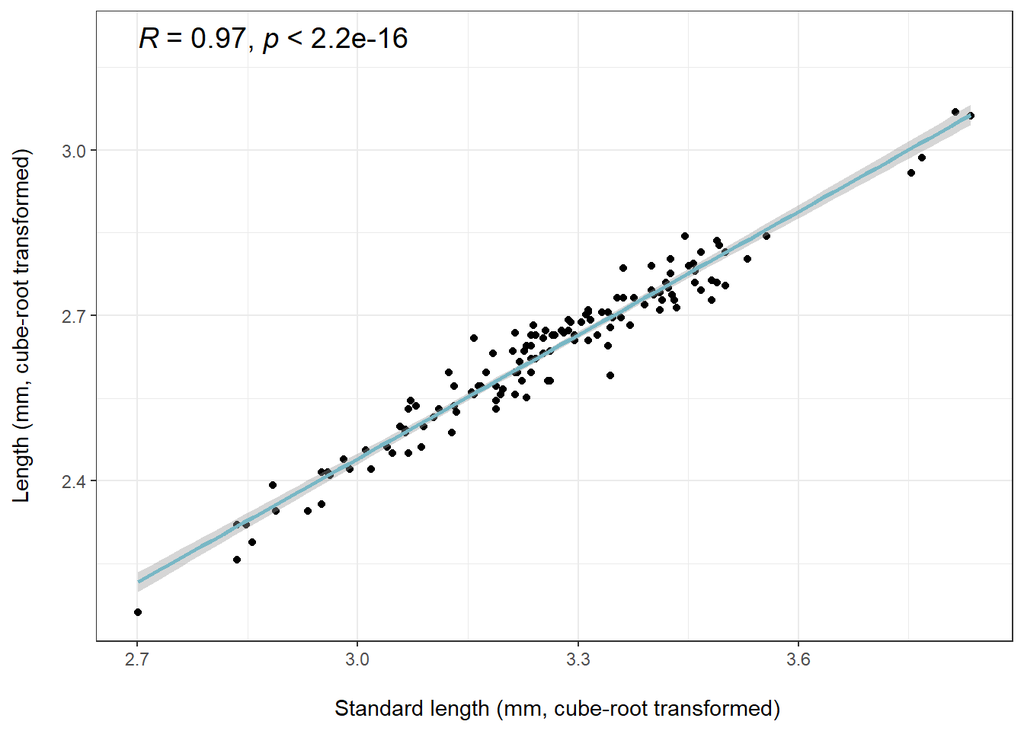

```r
reg.lat.PreDL <- lm(lat$cbR_PreDL ~ lat$cbR_SL)
sd.lat.PreDL <- rstandard(reg.lat.PreDL)
reg.lat.PreDL.plot <- ggplot(lat, aes(x = cbR_SL, y = cbR_PreDL)) +
  geom_point() +
  stat_smooth(method = "lm", col = "#78B7C5") +
  stat_cor(label.y = 3.2, size=5)+ theme_bw() + labs(x= "\n Standard length (mm, cube-root transformed)", y="Length (mm, cube-root transformed)\n")
reg.lat.PreDL.plot
```

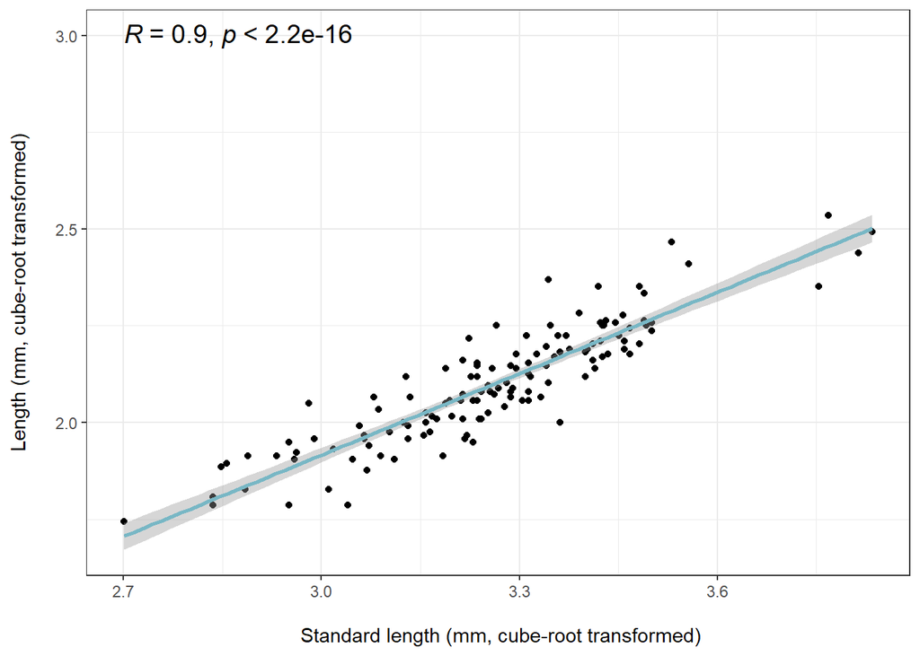

```r
reg.lat.DbL <- lm(lat$cbR_DbL ~ lat$cbR_SL)
sd.lat.DbL <- rstandard(reg.lat.DbL)
reg.lat.DbL.plot <- ggplot(lat, aes(x = cbR_SL, y = cbR_DbL)) +
  geom_point() +
  stat_smooth(method = "lm", col = "#78B7C5") +
  stat_cor(label.y = 3, size=5)+ theme_bw() + labs(x= "\n Standard length (mm, cube-root transformed)", y="Length (mm, cube-root transformed)\n")
reg.lat.DbL.plot
```

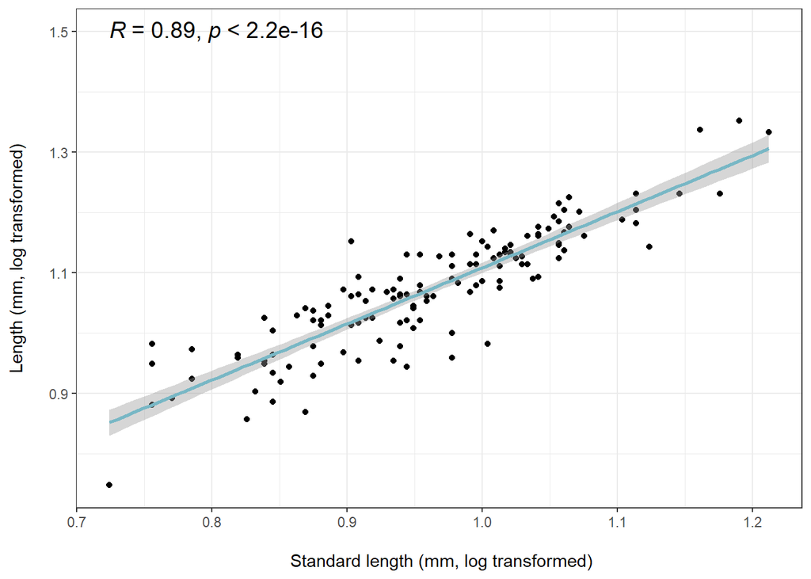

```r
reg.lat.HL <- lm(lat$HL_log ~ lat$SL_log)
sd.lat.HL <- rstandard(reg.lat.HL)
reg.lat.HL.plot <- ggplot(lat, aes(x = SL_log, y = HL_log)) +
  geom_point() +
  stat_smooth(method = "lm", col = "#78B7C5") +
  stat_cor(label.y = 1.5, size=5)+ theme_bw() + labs(x= "\n Standard length (mm, log transformed)", y="Length (mm, log transformed)\n")
reg.lat.HL.plot
```

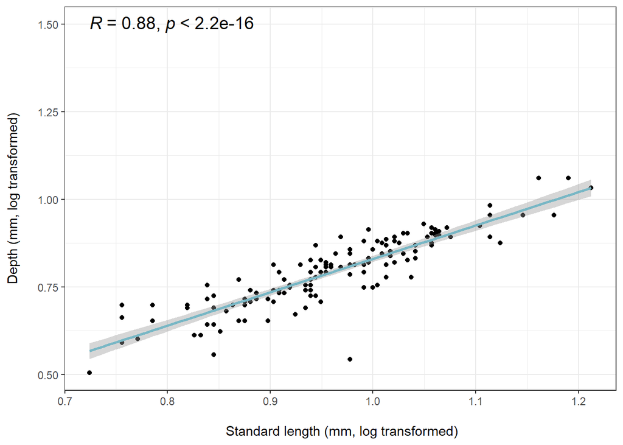

```r
reg.lat.HD <- lm(lat$HD_log ~ lat$SL_log)
sd.lat.HD <- rstandard(reg.lat.HD)
reg.lat.HD.plot <- ggplot(lat, aes(x = SL_log, y = HD_log)) +
  geom_point() +
  stat_smooth(method = "lm", col = "#78B7C5") +
  stat_cor(label.y = 1.5, size=5)+ theme_bw() + labs(x= "\n Standard length (mm, log transformed)", y="Depth (mm, log transformed)\n")
reg.lat.HD.plot
```

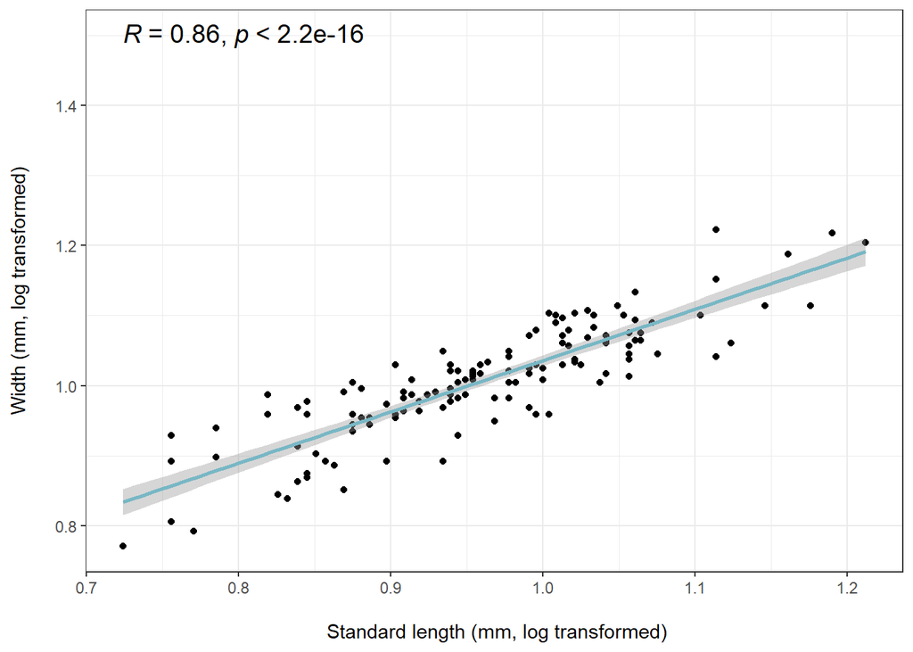

```r
reg.lat.HW <- lm(lat$HW_log ~ lat$SL_log)
sd.lat.HW <- rstandard(reg.lat.HW)
reg.lat.HW.plot <- ggplot(lat, aes(x = SL_log, y = HW_log)) +
  geom_point() +
  stat_smooth(method = "lm", col = "#78B7C5") +
  stat_cor(label.y = 1.5, size=5)+ theme_bw() + labs(x= "\n Standard length (mm, log transformed)", y="Width (mm, log transformed)\n")
reg.lat.HW.plot
```

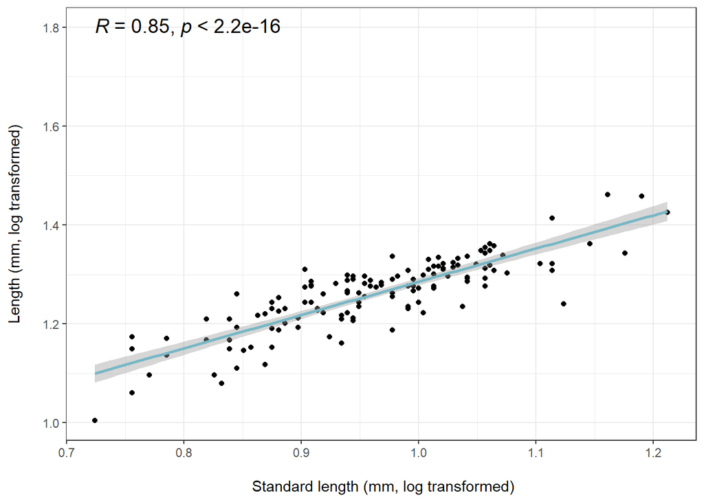

```r
reg.lat.SnL <- lm(lat$SnL_log ~ lat$SL_log)
sd.lat.SnL <- rstandard(reg.lat.SnL)
reg.lat.SnL.plot <- ggplot(lat, aes(x = SL_log, y = SnL_log)) +
  geom_point() +
  stat_smooth(method = "lm", col = "#78B7C5") +
  stat_cor(label.y = 1.8, size=5)+ theme_bw() + labs(x= "\n Standard length (mm, log transformed)", y="Length (mm, log transformed)\n")
reg.lat.SnL.plot
```

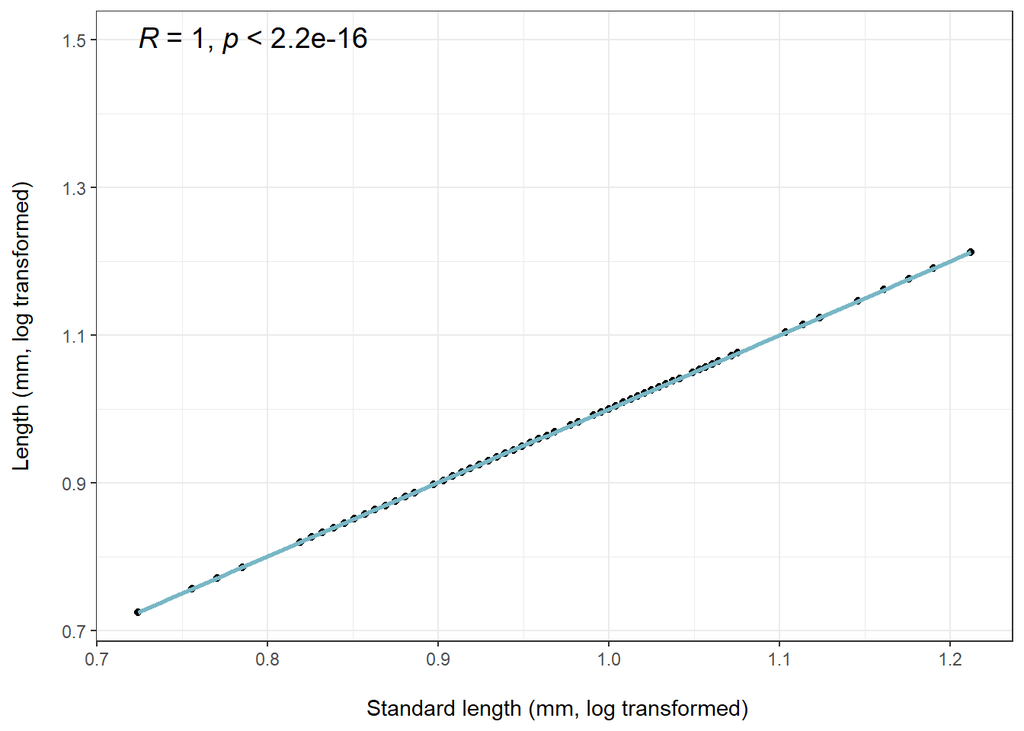

```r
reg.lat.OL <- lm(lat$OL_log ~ lat$SL_log)
sd.lat.OL <- rstandard(reg.lat.OL)
reg.lat.OL.plot <- ggplot(lat, aes(x = SL_log, y = OL_log)) +
  geom_point() +
  stat_smooth(method = "lm", col = "#78B7C5") +
  stat_cor(label.y = 1.5, size=5)+ theme_bw() + labs(x= "\n Standard length (mm, log transformed)", y="Length (mm, log transformed)\n")
reg.lat.OL.plot
```

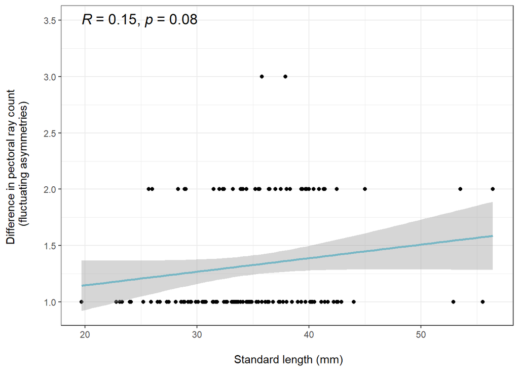

```r
reg.lat.FLA <- lm(lat$FLA ~ lat$SL)
sd.lat.FLA <- rstandard(reg.lat.FLA)
reg.lat.FLA.plot <- ggplot(lat, aes(x = SL, y = FLA)) +
  geom_point() +
  stat_smooth(method = "lm", col = "#78B7C5") +
  stat_cor(label.y = 3.5, size=5)+ theme_bw() + labs(x= "\n Standard length (mm)", y="Difference in pectoral ray count \n (fluctuating asymmetries)\n")
reg.lat.FLA.plot
```

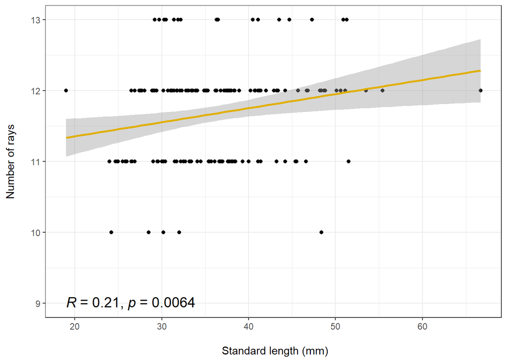

```r
##### FORM #####

reg.form.D <- lm(form$D ~ form$SL)
sd.form.D <- rstandard(reg.form.D)
reg.form.D.plot <- ggplot(form, aes(x =SL, y = D)) +
  geom_point() +
  stat_smooth(method = "lm", col = "#E1AF00") +
  stat_cor(label.y = 9, size=5)+ theme_bw() + labs(x= "\n Standard length (mm)", y="Number of rays\n")
reg.form.D.plot
```

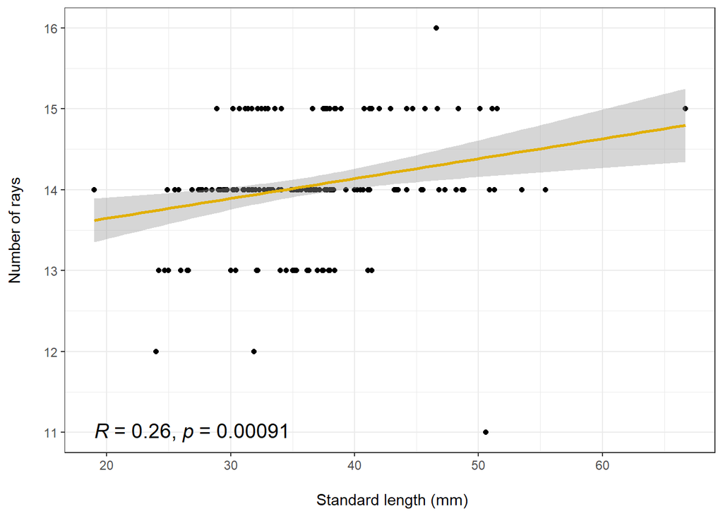

```r
reg.form.P1 <- lm(form$P1 ~ form$SL)
sd.form.P1 <- rstandard(reg.form.P1)
reg.form.P1.plot <- ggplot(form, aes(x = SL, y = P1)) +
  geom_point() +
  stat_smooth(method = "lm", col = "#E1AF00") +
  stat_cor(label.y = 11, size=5)+ theme_bw() + labs(x= "\n Standard length (mm)", y="Number of rays\n")
reg.form.P1.plot
```

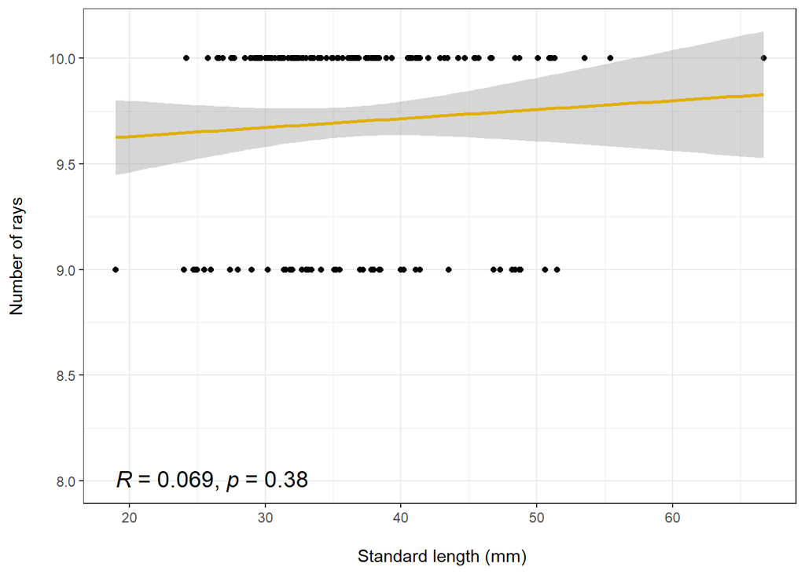

```r
reg.form.A <- lm(form$A ~ form$SL)
sd.form.A <- rstandard(reg.form.A)
reg.form.A.plot <- ggplot(form, aes(x = SL, y = A)) +
  geom_point() +
  stat_smooth(method = "lm", col = "#E1AF00") +
  stat_cor(label.y = 8, size=5)+ theme_bw() + labs(x= "\n Standard length (mm)", y="Number of rays\n")
reg.form.A.plot
```

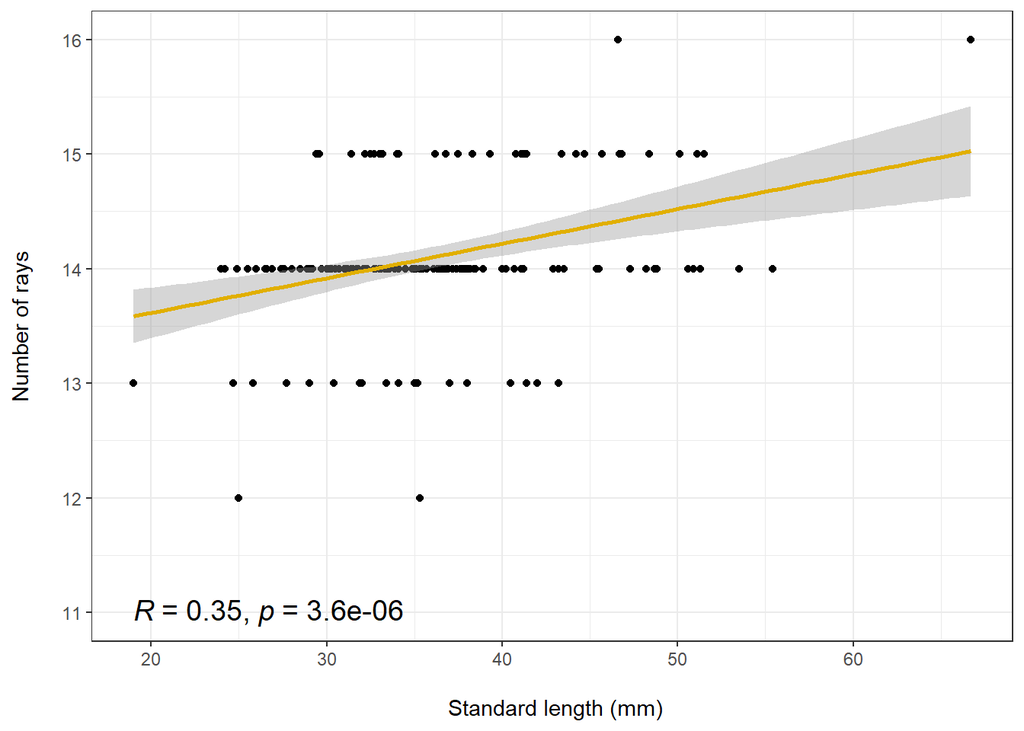

```r
reg.form.P1.R <- lm(form$P1.R ~ form$SL)
sd.form.P1.R <- rstandard(reg.form.P1.R)
reg.form.P1.R.plot <- ggplot(form, aes(x = SL, y = P1.R)) +
  geom_point() +
  stat_smooth(method = "lm", col = "#E1AF00") +
  stat_cor(label.y = 11, size=5)+ theme_bw() + labs(x= "\n Standard length (mm)", y="Number of rays\n")
reg.form.P1.R.plot
```

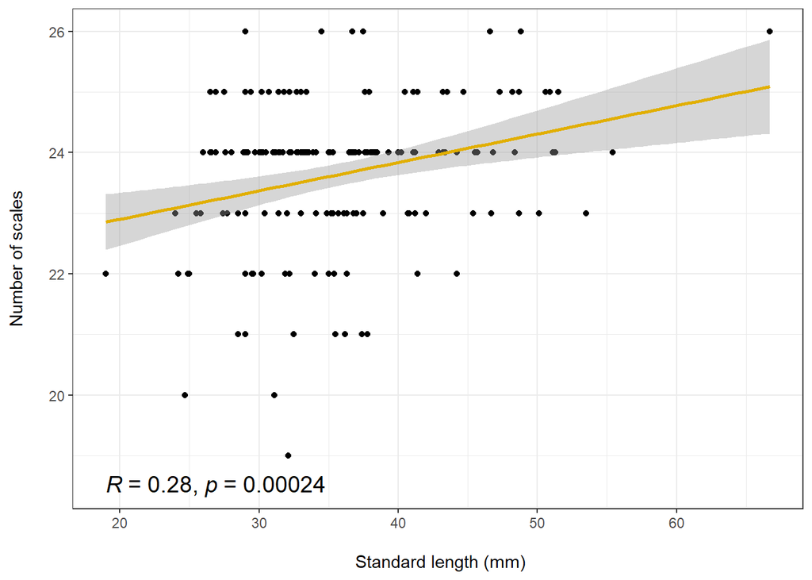

```r
reg.form.LLSC <- lm(form$LLSC ~ form$SL)
sd.form.LLSC <- rstandard(reg.form.LLSC)
reg.form.LLSC.plot <- ggplot(form, aes(x = SL, y = LLSC)) +
  geom_point() +
  stat_smooth(method = "lm", col = "#E1AF00") +
  stat_cor(label.y = 18.5, size=5)+ theme_bw() + labs(x= "\n Standard length (mm)", y="Number of scales\n")
reg.form.LLSC.plot
```

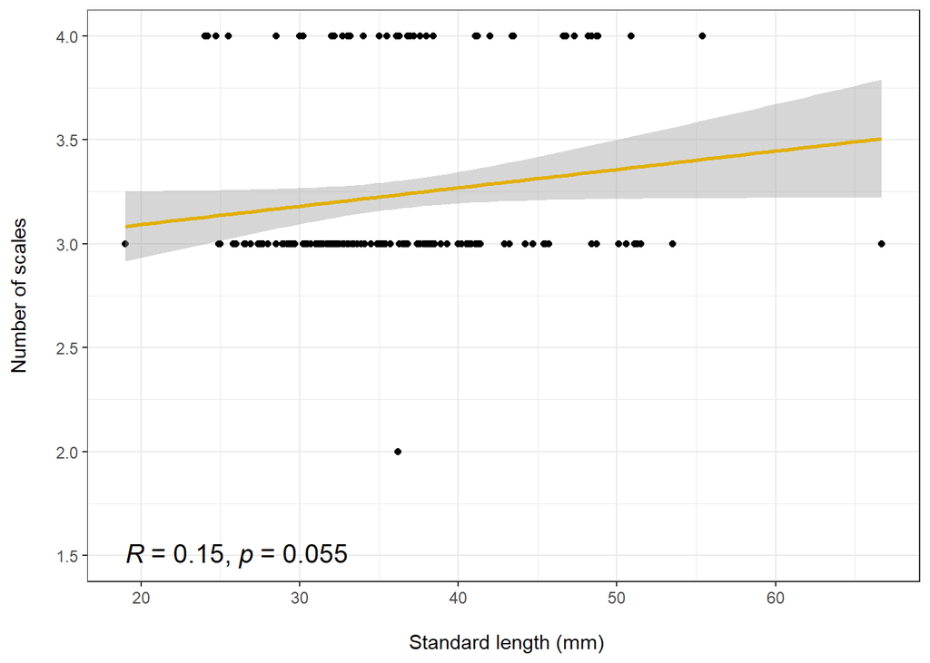

```r
reg.form.SALL <- lm(form$SALL ~ form$SL)
sd.form.SALL <- rstandard(reg.form.SALL)
reg.form.SALL.plot <- ggplot(form, aes(x = SL, y = SALL)) +
  geom_point() +
  stat_smooth(method = "lm", col = "#E1AF00") +
  stat_cor(label.y = 1.5, size=5)+ theme_bw() + labs(x= "\n Standard length (mm)", y="Number of scales\n")
reg.form.SALL.plot
```

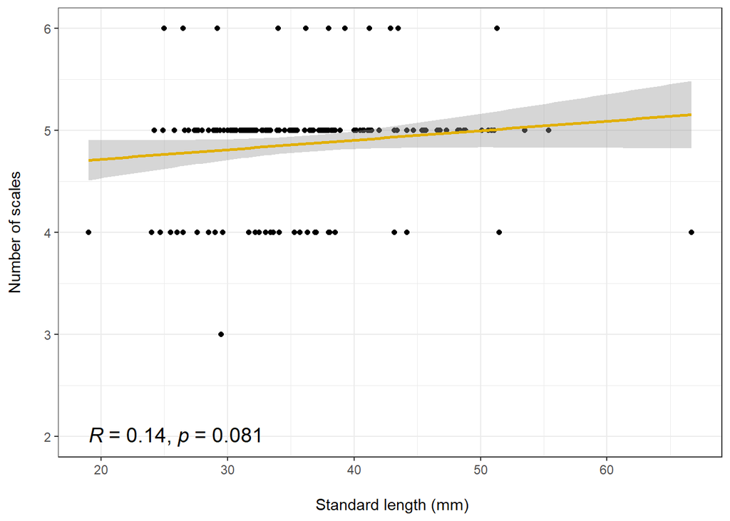

```r
reg.form.SBLL <- lm(form$SBLL ~ form$SL)
sd.form.SBLL <- rstandard(reg.form.SBLL)
reg.form.SBLL.plot <- ggplot(form, aes(x = SL, y = SBLL)) +
  geom_point() +
  stat_smooth(method = "lm", col = "#E1AF00") +
  stat_cor(label.y = 2, size=5)+ theme_bw() + labs(x= "\n Standard length (mm)", y="Number of scales\n")
reg.form.SBLL.plot
```

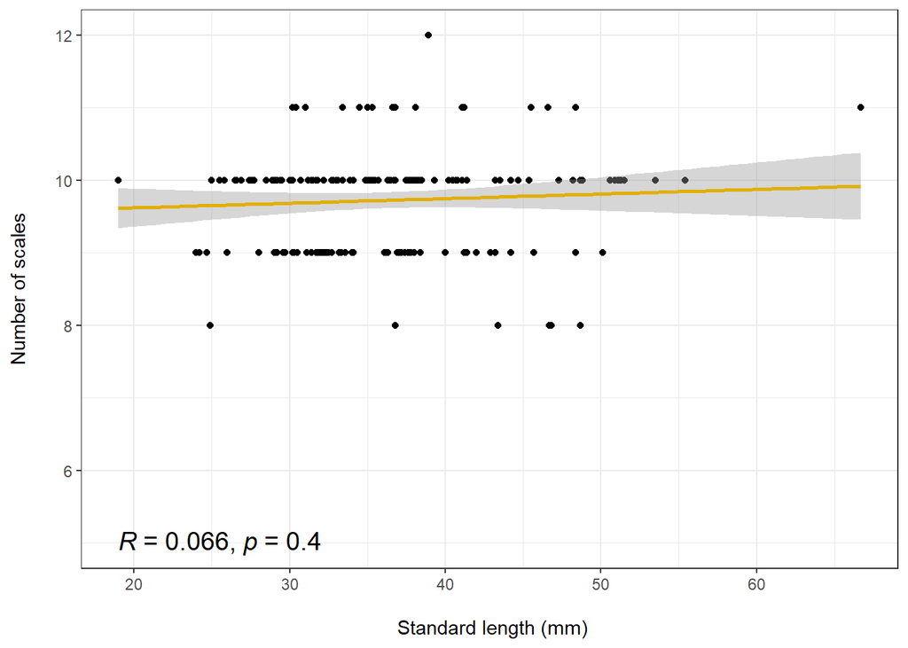

```r
reg.form.SBDF <- lm(form$SBDF ~ form$SL)
sd.form.SBDF <- rstandard(reg.form.SBDF)
reg.form.SBDF.plot <- ggplot(form, aes(x = SL, y = SBDF)) +
  geom_point() +
  stat_smooth(method = "lm", col = "#E1AF00") +
  stat_cor(label.y = 5, size=5)+ theme_bw() + labs(x= "\n Standard length (mm)", y="Number of scales\n")
reg.form.SBDF.plot
```

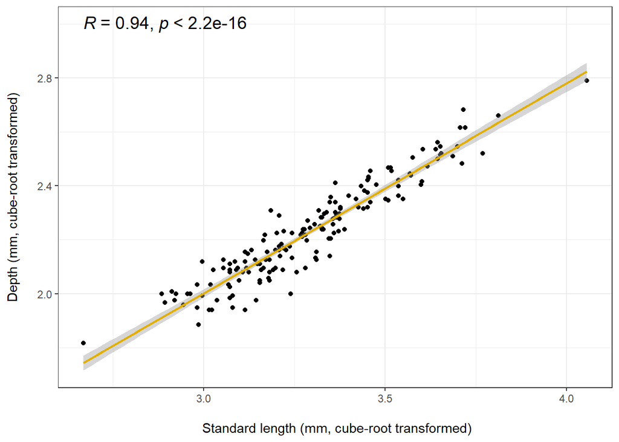

```r
reg.form.BD <- lm(form$cbR_BD ~ form$cbR_SL)
sd.form.BD <- rstandard(reg.form.BD)
reg.form.BD.plot <- ggplot(form, aes(x = cbR_SL, y = cbR_BD)) +
  geom_point() +
  stat_smooth(method = "lm", col = "#E1AF00") +
  stat_cor(label.y = 3, size=5)+ theme_bw() + labs(x= "\n Standard length (mm, cube-root transformed)", y="Depth (mm, cube-root transformed)\n")
reg.form.BD.plot
```

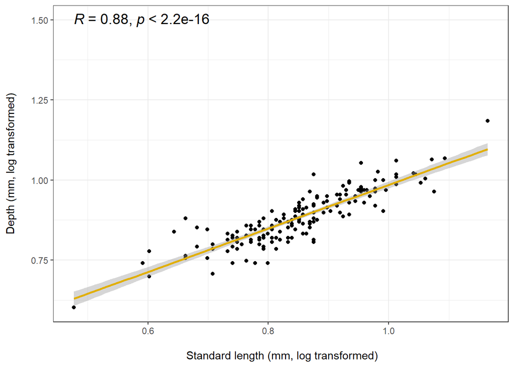

```r
reg.form.CPD <- lm(form$CPD_log ~ form$SL_log)
sd.form.CPD <- rstandard(reg.form.CPD)
reg.form.CPD.plot <- ggplot(form, aes(x = SL_log, y = CPD_log)) +
  geom_point() +
  stat_smooth(method = "lm", col = "#E1AF00") +
  stat_cor(label.y = 1.5, size=5)+ theme_bw() + labs(x= "\n Standard length (mm, log transformed)", y="Depth (mm, log transformed)\n")
reg.form.CPD.plot
```

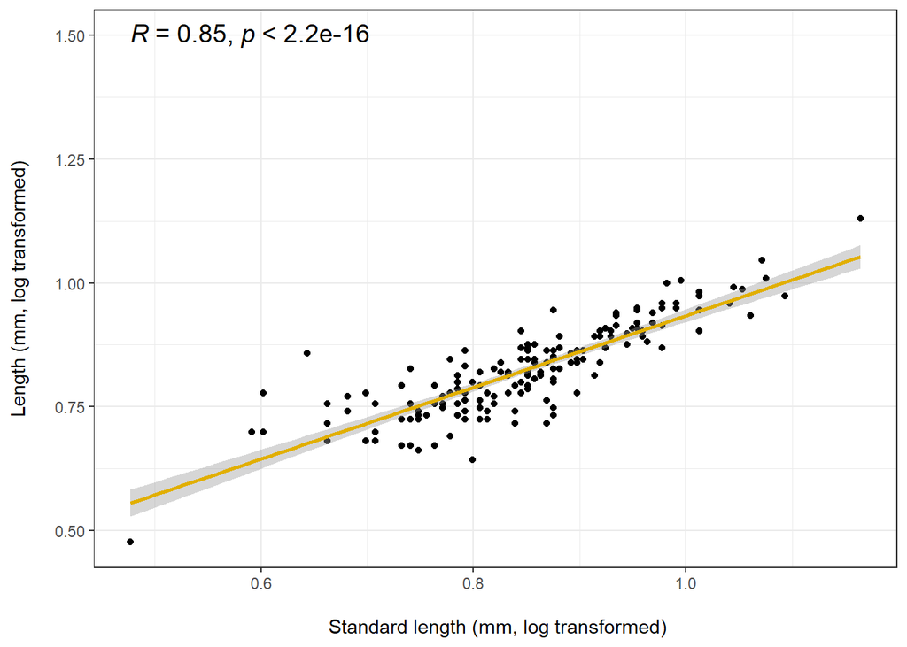

```r
reg.form.CPL <- lm(form$CPL_log ~ form$SL_log)
sd.form.CPL <- rstandard(reg.form.CPL)
reg.form.CPL.plot <- ggplot(form, aes(x = SL_log, y = CPL_log)) +
  geom_point() +
  stat_smooth(method = "lm", col = "#E1AF00") +
  stat_cor(label.y = 1.5, size=5)+ theme_bw() + labs(x= "\n Standard length (mm, log transformed)", y="Length (mm, log transformed)\n")
reg.form.CPL.plot
```

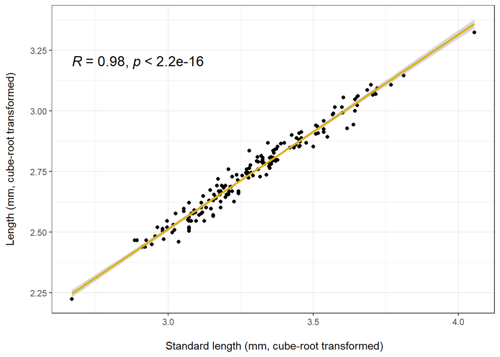

```r
reg.form.PreDL <- lm(form$cbR_PreDL ~ form$cbR_SL)
sd.form.PreDL <- rstandard(reg.form.PreDL)
reg.form.PreDL.plot <- ggplot(form, aes(x = cbR_SL, y = cbR_PreDL)) +
  geom_point() +
  stat_smooth(method = "lm", col = "#E1AF00") +
  stat_cor(label.y = 3.2, size=5)+ theme_bw() + labs(x= "\n Standard length (mm, cube-root transformed)", y="Length (mm, cube-root transformed)\n")
reg.form.PreDL.plot
```

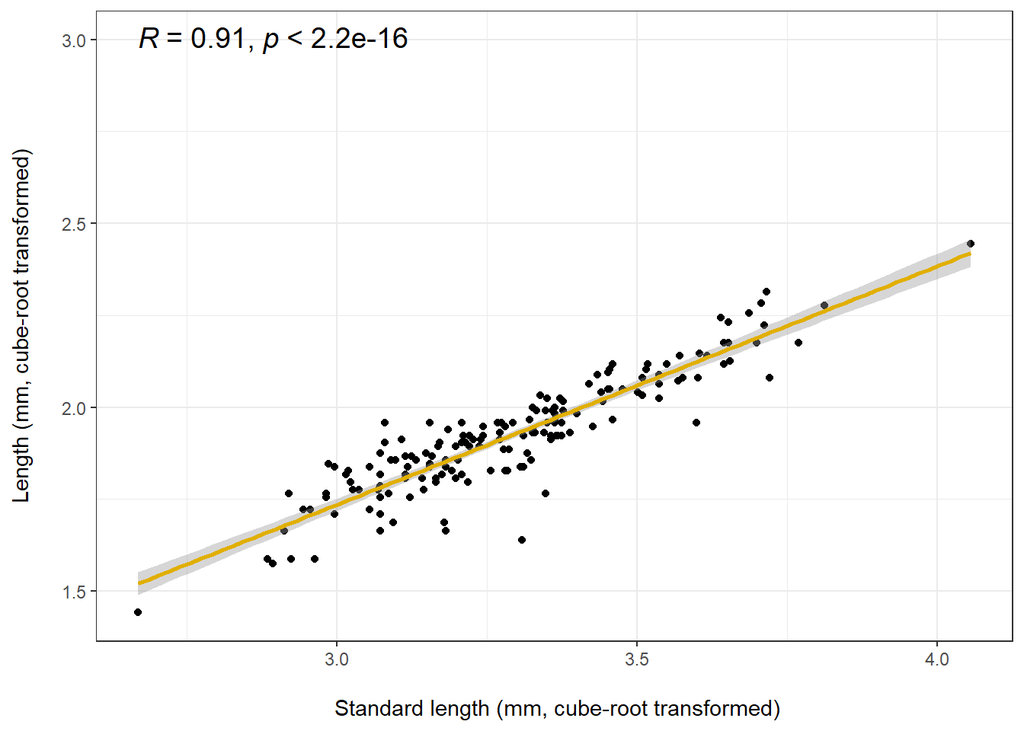

```r
reg.form.DbL <- lm(form$cbR_DbL ~ form$cbR_SL)
sd.form.DbL <- rstandard(reg.form.DbL)
reg.form.DbL.plot <- ggplot(form, aes(x = cbR_SL, y = cbR_DbL)) +
  geom_point() +
  stat_smooth(method = "lm", col = "#E1AF00") +
  stat_cor(label.y = 3, size=5) + theme_bw() + labs(x= "\n Standard length (mm, cube-root transformed)", y="Length (mm, cube-root transformed)\n")
reg.form.DbL.plot
```